# Project_Group11

#installing packages install.packages(“readxl”) install.packages(“tidyr”)

#attaching module libraries library(dplyr) library(readxl) library(tidyr)

```r
#-------------------------[ DATA PREPROCESSING STEPS ]--------------------------
#--------------------------[ 1. IMPORTING DATASET ]-----------------------------

# Read data
df <- read_excel("/Users/tataurosetta/Downloads/rStudio Working Directory/RStudio Datasets/AirQualityUCI.xlsx")

#viewing default dataset
View(df)

# Checking datatypes of individual columns
str(df)
```

```
tibble [9,357 × 15] (S3: tbl_df/tbl/data.frame)
 $ Date         : POSIXct[1:9357], format: "2004-03-10" "2004-03-10" "2004-03-10" "2004-03-10" ...
 $ Time         : POSIXct[1:9357], format: "1899-12-31 18:00:00" "1899-12-31 19:00:00" "1899-12-31 20:00:00" "1899-12-31 21:00:00" ...
 $ CO(GT)       : num [1:9357] 2.6 2 2.2 2.2 1.6 1.2 1.2 1 0.9 0.6 ...
 $ PT08.S1(CO)  : num [1:9357] 1360 1292 1402 1376 1272 ...
 $ NMHC(GT)     : num [1:9357] 150 112 88 80 51 38 31 31 24 19 ...
 $ C6H6(GT)     : num [1:9357] 11.88 9.4 9 9.23 6.52 ...
 $ PT08.S2(NMHC): num [1:9357] 1046 955 939 948 836 ...
 $ NOx(GT)      : num [1:9357] 166 103 131 172 131 89 62 62 45 -200 ...
 $ PT08.S3(NOx) : num [1:9357] 1056 1174 1140 1092 1205 ...
 $ NO2(GT)      : num [1:9357] 113 92 114 122 116 96 77 76 60 -200 ...
 $ PT08.S4(NO2) : num [1:9357] 1692 1559 1554 1584 1490 ...
 $ PT08.S5(O3)  : num [1:9357] 1268 972 1074 1203 1110 ...
 $ T            : num [1:9357] 13.6 13.3 11.9 11 11.2 ...
 $ RH           : num [1:9357] 48.9 47.7 54 60 59.6 ...
 $ AH           : num [1:9357] 0.758 0.725 0.75 0.787 0.789 ...
```

```r
# Checking summary of the dataset
summary(df)
```

```
      Date                             Time                            CO(GT)         PT08.S1(CO)      NMHC(GT)
 Min.   :2004-03-10 00:00:00.00   Min.   :1899-12-31 00:00:00.00   Min.   :-200.00   Min.   :-200   Min.   :-200.0
 1st Qu.:2004-06-16 00:00:00.00   1st Qu.:1899-12-31 05:00:00.00   1st Qu.:   0.60   1st Qu.: 921   1st Qu.:-200.0
 Median :2004-09-21 00:00:00.00   Median :1899-12-31 11:00:00.00   Median :   1.50   Median :1052   Median :-200.0
 Mean   :2004-09-21 04:30:05.19   Mean   :1899-12-31 11:29:55.80   Mean   : -34.21   Mean   :1049   Mean   :-159.1
 3rd Qu.:2004-12-28 00:00:00.00   3rd Qu.:1899-12-31 18:00:00.00   3rd Qu.:   2.60   3rd Qu.:1221   3rd Qu.:-200.0
 Max.   :2005-04-04 00:00:00.00   Max.   :1899-12-31 23:00:00.00   Max.   :  11.90   Max.   :2040   Max.   :1189.0
    C6H6(GT)        PT08.S2(NMHC)       NOx(GT)        PT08.S3(NOx)       NO2(GT)         PT08.S4(NO2)   PT08.S5(O3)
 Min.   :-200.000   Min.   :-200.0   Min.   :-200.0   Min.   :-200.0   Min.   :-200.00   Min.   :-200   Min.   :-200.0
 1st Qu.:   4.005   1st Qu.: 711.0   1st Qu.:  50.0   1st Qu.: 637.0   1st Qu.:  53.00   1st Qu.:1185   1st Qu.: 699.8
 Median :   7.887   Median : 894.5   Median : 141.0   Median : 794.2   Median :  96.00   Median :1446   Median : 942.0
 Mean   :   1.866   Mean   : 894.5   Mean   : 168.6   Mean   : 794.9   Mean   :  58.14   Mean   :1391   Mean   : 975.0
 3rd Qu.:  13.636   3rd Qu.:1104.8   3rd Qu.: 284.2   3rd Qu.: 960.2   3rd Qu.: 133.00   3rd Qu.:1662   3rd Qu.:1255.2
 Max.   :  63.741   Max.   :2214.0   Max.   :1479.0   Max.   :2682.8   Max.   : 339.70   Max.   :2775   Max.   :2522.8
       T                  RH                AH
 Min.   :-200.000   Min.   :-200.00   Min.   :-200.0000
 1st Qu.:  10.950   1st Qu.:  34.05   1st Qu.:   0.6923
 Median :  17.200   Median :  48.55   Median :   0.9768
 Mean   :   9.777   Mean   :  39.48   Mean   :  -6.8376
 3rd Qu.:  24.075   3rd Qu.:  61.88   3rd Qu.:   1.2962
 Max.   :  44.600   Max.   :  88.72   Max.   :   2.2310
```

```r
# Check for missing values
sum(is.na(df))
```

```
[1] 0
```

```r
#--------------------------[ 2. HANDLING MISSING DATA ]-------------------------

# Changing -200 value to null value
df[df == -200] = NA

# Checking summary of the dataset after replacing -200 (or missing values)
#with NA
summary(df)
```

```
      Date                             Time                            CO(GT)        PT08.S1(CO)        NMHC(GT)
 Min.   :2004-03-10 00:00:00.00   Min.   :1899-12-31 00:00:00.00   Min.   : 0.100   Min.   : 647.2   Min.   :   7.0
 1st Qu.:2004-06-16 00:00:00.00   1st Qu.:1899-12-31 05:00:00.00   1st Qu.: 1.100   1st Qu.: 936.8   1st Qu.:  67.0
 Median :2004-09-21 00:00:00.00   Median :1899-12-31 11:00:00.00   Median : 1.800   Median :1063.0   Median : 150.0
 Mean   :2004-09-21 04:30:05.19   Mean   :1899-12-31 11:29:55.80   Mean   : 2.153   Mean   :1099.7   Mean   : 218.8
 3rd Qu.:2004-12-28 00:00:00.00   3rd Qu.:1899-12-31 18:00:00.00   3rd Qu.: 2.900   3rd Qu.:1231.2   3rd Qu.: 297.0
 Max.   :2005-04-04 00:00:00.00   Max.   :1899-12-31 23:00:00.00   Max.   :11.900   Max.   :2039.8   Max.   :1189.0
                                                                   NA's   :1683     NA's   :366      NA's   :8443
    C6H6(GT)      PT08.S2(NMHC)       NOx(GT)        PT08.S3(NOx)       NO2(GT)       PT08.S4(NO2)   PT08.S5(O3)
 Min.   : 0.149   Min.   : 383.2   Min.   :   2.0   Min.   : 322.0   Min.   :  2.0   Min.   : 551   Min.   : 221.0
 1st Qu.: 4.437   1st Qu.: 734.4   1st Qu.:  98.0   1st Qu.: 657.9   1st Qu.: 78.0   1st Qu.:1227   1st Qu.: 731.4
 Median : 8.240   Median : 909.0   Median : 179.8   Median : 805.5   Median :109.0   Median :1463   Median : 963.2
 Mean   :10.083   Mean   : 939.0   Mean   : 246.9   Mean   : 835.4   Mean   :113.1   Mean   :1456   Mean   :1022.8
 3rd Qu.:13.989   3rd Qu.:1116.2   3rd Qu.: 326.0   3rd Qu.: 969.2   3rd Qu.:142.0   3rd Qu.:1674   3rd Qu.:1273.4
 Max.   :63.742   Max.   :2214.0   Max.   :1479.0   Max.   :2682.8   Max.   :339.7   Max.   :2775   Max.   :2522.8
 NA's   :366      NA's   :366      NA's   :1639     NA's   :366      NA's   :1642    NA's   :366    NA's   :366
       T               RH               AH
 Min.   :-1.90   Min.   : 9.175   Min.   :0.1847
 1st Qu.:11.79   1st Qu.:35.812   1st Qu.:0.7368
 Median :17.75   Median :49.550   Median :0.9954
 Mean   :18.32   Mean   :49.232   Mean   :1.0255
 3rd Qu.:24.40   3rd Qu.:62.500   3rd Qu.:1.3137
 Max.   :44.60   Max.   :88.725   Max.   :2.2310
 NA's   :366     NA's   :366      NA's   :366
```

```r
#Viewing dataset after replacing -200 (or missing values) with NA
View(df)

#---[ 3. Replace the missing data with the average of the feature in which the data
#is missing: ]------------------------------------------------------------------

# Imputing mean for NA values
df <- df %>%
  mutate_if(is.numeric, ~replace_na(.,mean(., na.rm = TRUE)))

# Checking summary of the dataset after replacing NA with mean of data
summary(df)
```

```
      Date                             Time                            CO(GT)        PT08.S1(CO)        NMHC(GT)
 Min.   :2004-03-10 00:00:00.00   Min.   :1899-12-31 00:00:00.00   Min.   : 0.100   Min.   : 647.2   Min.   :   7.0
 1st Qu.:2004-06-16 00:00:00.00   1st Qu.:1899-12-31 05:00:00.00   1st Qu.: 1.200   1st Qu.: 941.2   1st Qu.: 218.8
 Median :2004-09-21 00:00:00.00   Median :1899-12-31 11:00:00.00   Median : 2.153   Median :1074.5   Median : 218.8
 Mean   :2004-09-21 04:30:05.19   Mean   :1899-12-31 11:29:55.80   Mean   : 2.153   Mean   :1099.7   Mean   : 218.8
 3rd Qu.:2004-12-28 00:00:00.00   3rd Qu.:1899-12-31 18:00:00.00   3rd Qu.: 2.600   3rd Qu.:1221.2   3rd Qu.: 218.8
 Max.   :2005-04-04 00:00:00.00   Max.   :1899-12-31 23:00:00.00   Max.   :11.900   Max.   :2039.8   Max.   :1189.0
    C6H6(GT)      PT08.S2(NMHC)       NOx(GT)        PT08.S3(NOx)       NO2(GT)       PT08.S4(NO2)   PT08.S5(O3)
 Min.   : 0.149   Min.   : 383.2   Min.   :   2.0   Min.   : 322.0   Min.   :  2.0   Min.   : 551   Min.   : 221.0
 1st Qu.: 4.591   1st Qu.: 742.5   1st Qu.: 112.0   1st Qu.: 665.5   1st Qu.: 85.9   1st Qu.:1242   1st Qu.: 741.8
 Median : 8.593   Median : 923.2   Median : 229.0   Median : 817.5   Median :113.1   Median :1456   Median : 982.5
 Mean   :10.083   Mean   : 939.0   Mean   : 246.9   Mean   : 835.4   Mean   :113.1   Mean   :1456   Mean   :1022.8
 3rd Qu.:13.636   3rd Qu.:1104.8   3rd Qu.: 284.2   3rd Qu.: 960.2   3rd Qu.:133.0   3rd Qu.:1662   3rd Qu.:1255.2
 Max.   :63.741   Max.   :2214.0   Max.   :1479.0   Max.   :2682.8   Max.   :339.7   Max.   :2775   Max.   :2522.8
       T               RH               AH
 Min.   :-1.90   Min.   : 9.175   Min.   :0.1847
 1st Qu.:12.03   1st Qu.:36.550   1st Qu.:0.7461
 Median :18.27   Median :49.232   Median :1.0154
 Mean   :18.32   Mean   :49.232   Mean   :1.0255
 3rd Qu.:24.07   3rd Qu.:61.875   3rd Qu.:1.2962
 Max.   :44.60   Max.   :88.725   Max.   :2.2310
```

```r
View(df)
```

# After the necessary steps taken in data preprocessing above,

# we are performing visualizations on the features of the AirQualityIndex data

# Below is the code for plotting a box plot on the features

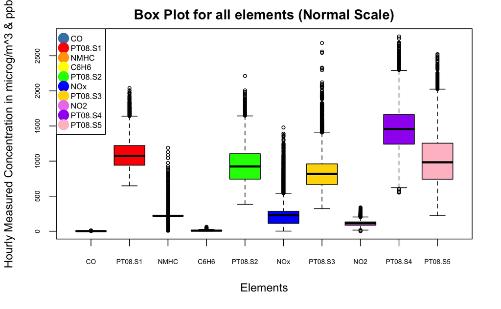

```r
#boxplot

#defining colors for all the elements
myColors <- c('steelblue','red','orange','yellow','green','blue','gold',
              'violet','purple','pink')

#defining legend labels
elements <- c("CO", "PT08.S1", "NMHC", "C6H6", "PT08.S2", "NOx", "PT08.S3",
              "NO2", "PT08.S4", "PT08.S5")

#------------[ plotting the side-side box plot on a normal scale ]--------------

boxplot_normal_scale <- boxplot(df$"CO(GT)", df$"PT08.S1(CO)",
            df$"NMHC(GT)", df$"C6H6(GT)", df$"PT08.S2(NMHC)",
            df$"NOx(GT)", df$"PT08.S3(NOx)", df$"NO2(GT)",
            df$"PT08.S4(NO2)", df$"PT08.S5(O3)", names=elements,
            horizontal = FALSE,
            main = "Box Plot for all elements (Normal Scale)",
            xlab = "Elements",
            ylab = "Hourly Measured Concentration in microg/m^3 & ppb",
            cex.axis = 0.59, cex.lab = 1.0, col=myColors, outcex = 0.62)

#defining the legend of the plot
legend("topleft", legend = c("CO", "PT08.S1", "NMHC", "C6H6", "PT08.S2",
                  "NOx", "PT08.S3", "NO2", "PT08.S4", "PT08.S5"),
                  col = c('steelblue','red','orange','yellow','green','blue',
                  'gold','violet','purple','pink'), bty = "o",
                  pch=20 , pt.cex = 3, cex = 0.7, horiz = FALSE, inset=0)
```

```r
NA
NA
NA
```

# In the above diagram, a side-by-side box plot has been plotted for the features

# from our data, more precisely only the elements sensed using metal oxide

# chemical sensory devices or sensors. The features that are relevant to this box

# plot are CO(GT) [ Carbon Monoxide ], PT08.S1(CO) [ Tin Oxide (CO Nominally Targeted) ],

# NMHC(GT) [Nonmethane hydrocarbons ( NMHC, such as ethane, ethene, propane, propene, and isoprene ) ],

# C6H6(GT) [ Benzene ], PT08.S2(NMHC) [ Titania ( NMHC Nominally Targeted)],

# NOx(GT) [ Nitric Oxide ], PT08.S3(NOx) [ Tungsten Oxide (NOx Nominally Targeted)],

# NO2(GT) [ Nitrogen Dioxide ], PT08.S4(NO2) [ Tungsten Oxide (NO2 Nominally Targeted) ],